# Taller 02 HTML: análisis integrado de indicadores educativos

Luisa Fernanda Velasco López 20212020106 Jairo Arturo Barrera Mosquera 20222020142 David lugo Piñeros 20222020180 Gabriela Martínez Silva 20231020205

2026-09-18

Este documento integra los resultados descriptivos del Taller 01 con el diagnóstico multivariado del Taller 02. Todo el análisis se ejecuta desde el dataset original y las tablas y figuras aparecen dentro de esta entrega HTML.

## 1. Diagnóstico general

Diagnóstico del dataset

| Filas | Variables | Razon_n_p | Porcentaje_faltantes | Filas_completas |
| --- | --- | --- | --- | --- |
| 5063 | 30 | 168.767 | 0 | 5063 |

Variables excluidas

| Variable | Motivo |
| --- | --- |
| APROBACIÓN_TRANSICIÓN | Constante o sin variación |
| REPROBACIÓN_TRANSICIÓN | Constante o sin variación |

Variables utilizadas

| Variable |
| --- |
| POBLACIÓN_5_16 |
| TASA_MATRICULACIÓN_5_16 |
| COBERTURA_NETA |
| COBERTURA_NETA_TRANSICIÓN |
| COBERTURA_NETA_PRIMARIA |
| COBERTURA_NETA_SECUNDARIA |
| COBERTURA_NETA_MEDIA |
| COBERTURA_BRUTA |
| COBERTURA_BRUTA_TRANSICIÓN |
| COBERTURA_BRUTA_PRIMARIA |
| COBERTURA_BRUTA_SECUNDARIA |
| COBERTURA_BRUTA_MEDIA |
| DESERCIÓN |
| DESERCIÓN_TRANSICIÓN |
| DESERCIÓN_PRIMARIA |
| DESERCIÓN_SECUNDARIA |
| DESERCIÓN_MEDIA |
| APROBACIÓN |
| APROBACIÓN_PRIMARIA |
| APROBACIÓN_SECUNDARIA |
| APROBACIÓN_MEDIA |
| REPROBACIÓN |
| REPROBACIÓN_PRIMARIA |
| REPROBACIÓN_SECUNDARIA |
| REPROBACIÓN_MEDIA |
| REPITENCIA |
| REPITENCIA_TRANSICIÓN |
| REPITENCIA_PRIMARIA |
| REPITENCIA_SECUNDARIA |
| REPITENCIA_MEDIA |

Se analizaron 5063 filas y 30 variables cuantitativas. El conjunto tiene 5063 filas completas y 0% de valores faltantes. Se excluyeron por ser constantes: APROBACIÓN_TRANSICIÓN, REPROBACIÓN_TRANSICIÓN.

## 2. Resumen estadístico integrado

La siguiente tabla reúne el resumen usado en ambos talleres: media, desviación estándar, extremos, mediana y faltantes por variable.

Resumen estadístico de variables cuantitativas

|  | Variable | Media | Desv_Est | Minimo | Mediana | Maximo | Faltantes |
| --- | --- | --- | --- | --- | --- | --- | --- |
| POBLACIÓN_5_16 | POBLACIÓN_5_16 | 3143.4514 | 2819.8031 | 1.0050 | 2220.0000 | 14013.0000 | 0 |
| TASA_MATRICULACIÓN_5_16 | TASA_MATRICULACIÓN_5_16 | 0.8319 | 0.1272 | 0.4538 | 0.8370 | 1.2347 | 0 |
| COBERTURA_NETA | COBERTURA_NETA | 0.8413 | 0.1146 | 0.5130 | 0.8514 | 1.1704 | 0 |
| COBERTURA_NETA_TRANSICIÓN | COBERTURA_NETA_TRANSICIÓN | 0.5753 | 0.1340 | 0.2061 | 0.5751 | 0.9461 | 0 |
| COBERTURA_NETA_PRIMARIA | COBERTURA_NETA_PRIMARIA | 0.8104 | 0.1202 | 0.4793 | 0.8130 | 1.1562 | 0 |
| COBERTURA_NETA_SECUNDARIA | COBERTURA_NETA_SECUNDARIA | 0.7148 | 0.1297 | 0.3421 | 0.7152 | 1.0759 | 0 |
| COBERTURA_NETA_MEDIA | COBERTURA_NETA_MEDIA | 0.4310 | 0.1211 | 0.0765 | 0.4345 | 0.7619 | 0 |
| COBERTURA_BRUTA | COBERTURA_BRUTA | 0.9473 | 0.1409 | 0.5523 | 0.9530 | 1.3556 | 0 |
| COBERTURA_BRUTA_TRANSICIÓN | COBERTURA_BRUTA_TRANSICIÓN | 0.8220 | 0.1766 | 0.3478 | 0.8190 | 1.3480 | 0 |
| COBERTURA_BRUTA_PRIMARIA | COBERTURA_BRUTA_PRIMARIA | 1.0010 | 0.1755 | 0.5340 | 1.0000 | 1.4775 | 0 |
| COBERTURA_BRUTA_SECUNDARIA | COBERTURA_BRUTA_SECUNDARIA | 1.0058 | 0.1812 | 0.5160 | 1.0060 | 1.4966 | 0 |
| COBERTURA_BRUTA_MEDIA | COBERTURA_BRUTA_MEDIA | 0.7584 | 0.1873 | 0.2370 | 0.7580 | 1.2800 | 0 |
| DESERCIÓN | DESERCIÓN | 0.0302 | 0.0160 | 0.0000 | 0.0280 | 0.0831 | 0 |
| DESERCIÓN_TRANSICIÓN | DESERCIÓN_TRANSICIÓN | 0.0292 | 0.0214 | 0.0000 | 0.0265 | 0.0952 | 0 |
| DESERCIÓN_PRIMARIA | DESERCIÓN_PRIMARIA | 0.0228 | 0.0154 | 0.0000 | 0.0202 | 0.0702 | 0 |
| DESERCIÓN_SECUNDARIA | DESERCIÓN_SECUNDARIA | 0.0406 | 0.0240 | 0.0000 | 0.0374 | 0.1136 | 0 |
| DESERCIÓN_MEDIA | DESERCIÓN_MEDIA | 0.0283 | 0.0187 | 0.0000 | 0.0252 | 0.0845 | 0 |
| APROBACIÓN | APROBACIÓN | 0.9337 | 0.0370 | 0.8089 | 0.9364 | 1.0000 | 0 |
| APROBACIÓN_PRIMARIA | APROBACIÓN_PRIMARIA | 0.9485 | 0.0342 | 0.8321 | 0.9535 | 1.0000 | 0 |
| APROBACIÓN_SECUNDARIA | APROBACIÓN_SECUNDARIA | 0.9047 | 0.0594 | 0.6981 | 0.9113 | 1.0000 | 0 |
| APROBACIÓN_MEDIA | APROBACIÓN_MEDIA | 0.9411 | 0.0368 | 0.8175 | 0.9463 | 1.0000 | 0 |
| REPROBACIÓN | REPROBACIÓN | 0.0361 | 0.0310 | 0.0000 | 0.0340 | 0.1504 | 0 |
| REPROBACIÓN_PRIMARIA | REPROBACIÓN_PRIMARIA | 0.0287 | 0.0282 | 0.0000 | 0.0230 | 0.1265 | 0 |
| REPROBACIÓN_SECUNDARIA | REPROBACIÓN_SECUNDARIA | 0.0548 | 0.0513 | 0.0000 | 0.0475 | 0.2391 | 0 |
| REPROBACIÓN_MEDIA | REPROBACIÓN_MEDIA | 0.0306 | 0.0302 | 0.0000 | 0.0228 | 0.1250 | 0 |
| REPITENCIA | REPITENCIA | 0.0244 | 0.0220 | 0.0000 | 0.0176 | 0.1007 | 0 |
| REPITENCIA_TRANSICIÓN | REPITENCIA_TRANSICIÓN | 0.0030 | 0.0056 | 0.0000 | 0.0000 | 0.0245 | 0 |
| REPITENCIA_PRIMARIA | REPITENCIA_PRIMARIA | 0.0233 | 0.0231 | 0.0000 | 0.0159 | 0.0994 | 0 |
| REPITENCIA_SECUNDARIA | REPITENCIA_SECUNDARIA | 0.0343 | 0.0338 | 0.0000 | 0.0233 | 0.1413 | 0 |
| REPITENCIA_MEDIA | REPITENCIA_MEDIA | 0.0117 | 0.0135 | 0.0000 | 0.0068 | 0.0532 | 0 |

## 3. Distribuciones: histogramas

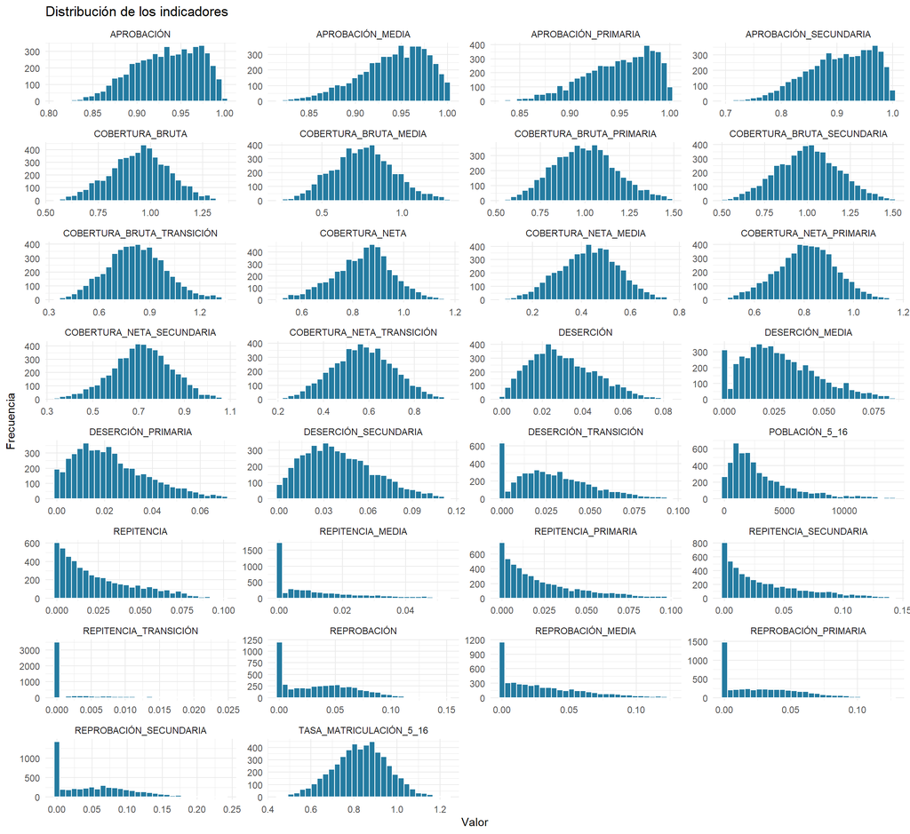

## 4. Comparación y valores atípicos

La normalización Min-Max permite comparar indicadores con escalas distintas. Las variables constantes se retiraron antes de normalizar para evitar rangos cero.

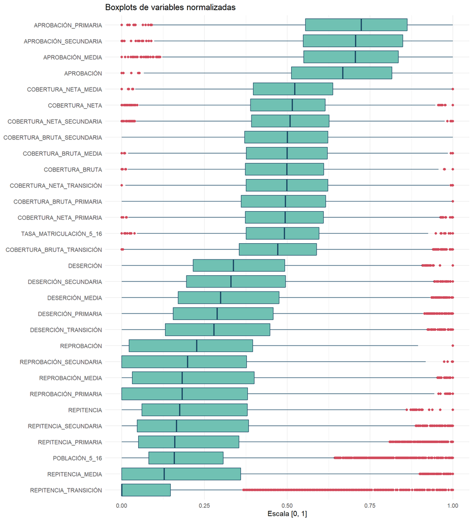

## 5. Relaciones bivariadas

Se muestran cinco relaciones seleccionadas del Taller 01. La línea discontinua representa el ajuste lineal y ayuda a visualizar la dirección de la asociación.

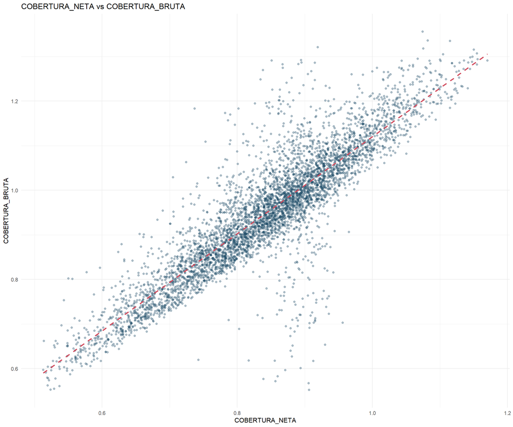

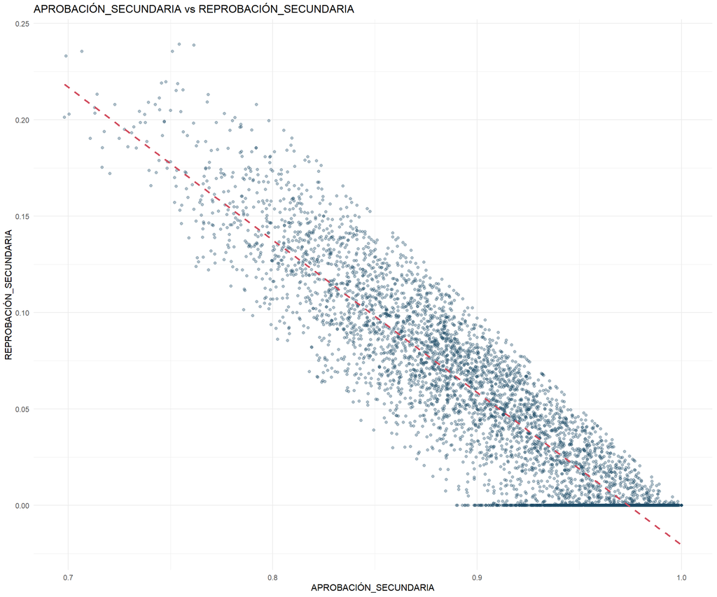

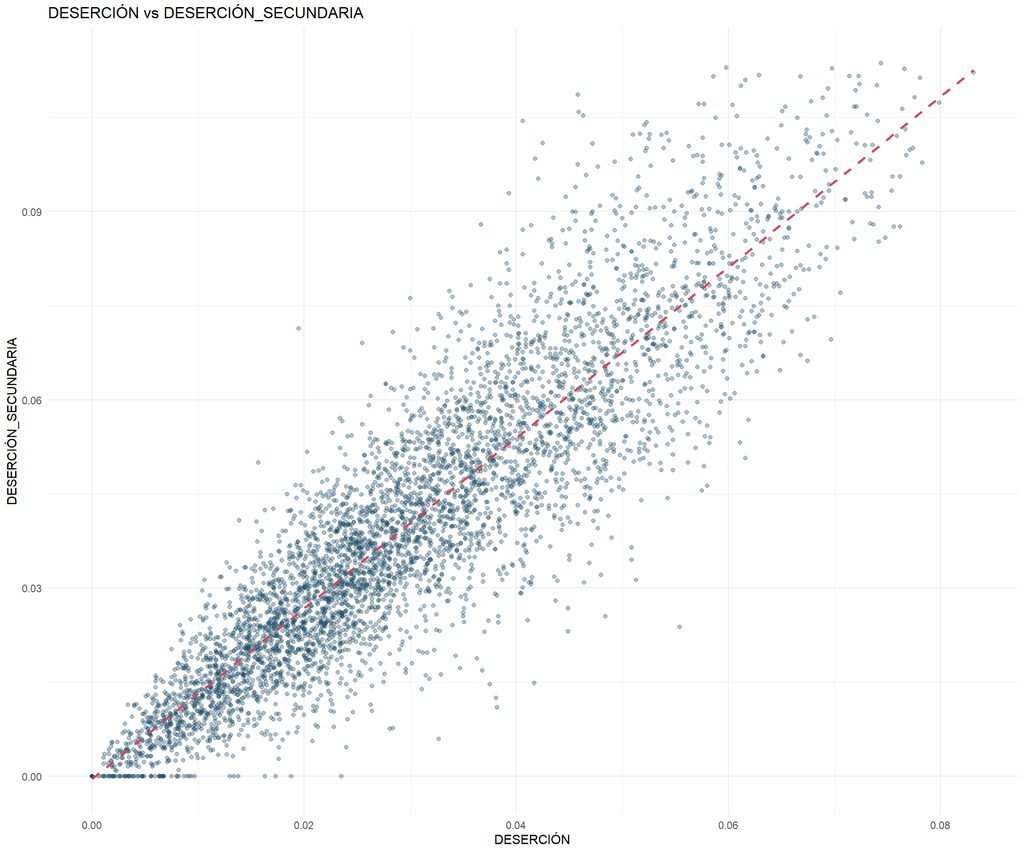

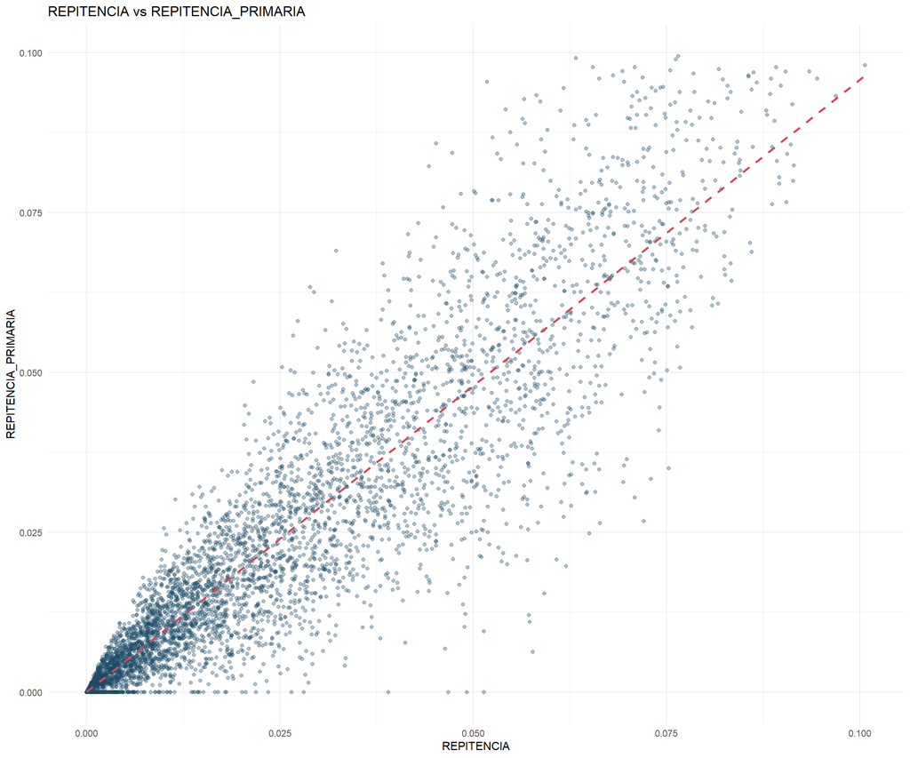

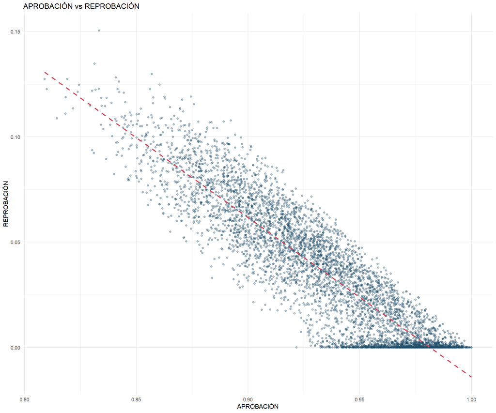

## 6. Correlaciones de Pearson

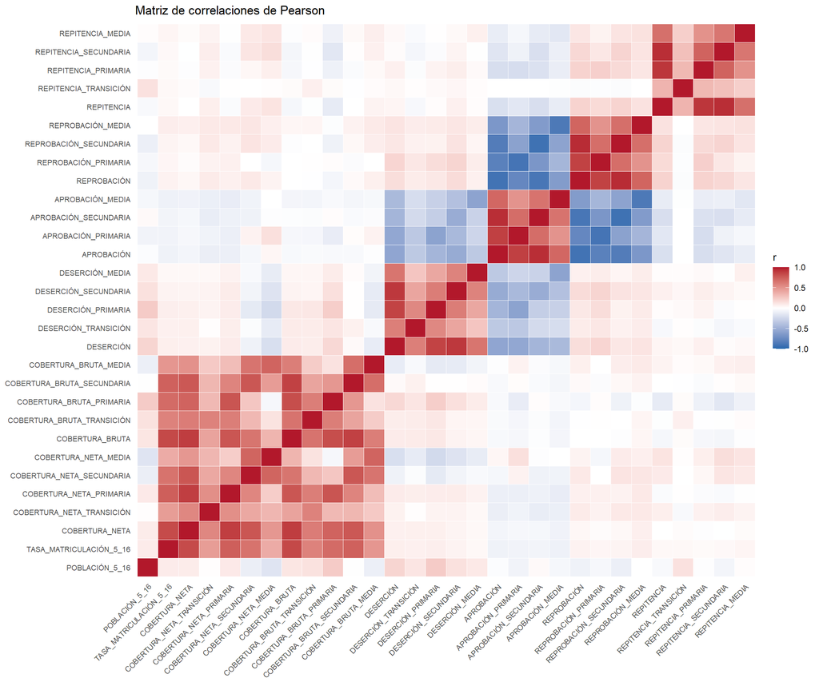

## 7. Covarianzas

Matriz de covarianzas

|  | POBLACIÓN_5_16 | TASA_MATRICULACIÓN_5_16 | COBERTURA_NETA | COBERTURA_NETA_TRANSICIÓN | COBERTURA_NETA_PRIMARIA | COBERTURA_NETA_SECUNDARIA | COBERTURA_NETA_MEDIA | COBERTURA_BRUTA | COBERTURA_BRUTA_TRANSICIÓN | COBERTURA_BRUTA_PRIMARIA | COBERTURA_BRUTA_SECUNDARIA | COBERTURA_BRUTA_MEDIA | DESERCIÓN | DESERCIÓN_TRANSICIÓN | DESERCIÓN_PRIMARIA | DESERCIÓN_SECUNDARIA | DESERCIÓN_MEDIA | APROBACIÓN | APROBACIÓN_PRIMARIA | APROBACIÓN_SECUNDARIA | APROBACIÓN_MEDIA | REPROBACIÓN | REPROBACIÓN_PRIMARIA | REPROBACIÓN_SECUNDARIA | REPROBACIÓN_MEDIA | REPITENCIA | REPITENCIA_TRANSICIÓN | REPITENCIA_PRIMARIA | REPITENCIA_SECUNDARIA | … |
| --- | --- | --- | --- | --- | --- | --- | --- | --- | --- | --- | --- | --- | --- | --- | --- | --- | --- | --- | --- | --- | --- | --- | --- | --- | --- | --- | --- | --- | --- | --- |
| POBLACIÓN_5_16 | 7951289.4350 | 32.5014 | 28.6370 | 3.6489 | 33.7918 | -37.7290 | -55.3312 | 46.6093 | 67.1821 | 119.2369 | -3.3729 | -51.1399 | 8.8734 | 7.2792 | 10.4943 | 9.4217 | 5.3312 | -1.8885 | -6.7050 | 4.3873 | -5.2552 | -6.9856 | -3.7911 | -13.8097 | -0.0749 | -2.2060 | 2.1667 | -0.8024 | -5.8132 | … |
| TASA_MATRICULACIÓN_5_16 | 32.5014 | 0.0162 | 0.0121 | 0.0078 | 0.0114 | 0.0108 | 0.0060 | 0.0151 | 0.0131 | 0.0154 | 0.0170 | 0.0117 | 0.0002 | 0.0002 | 0.0002 | 0.0002 | 0.0001 | -0.0004 | -0.0003 | -0.0005 | -0.0004 | 0.0002 | 0.0002 | 0.0003 | 0.0003 | 0.0001 | 0.0000 | 0.0001 | 0.0001 | … |
| COBERTURA_NETA | 28.6370 | 0.0121 | 0.0131 | 0.0086 | 0.0122 | 0.0117 | 0.0067 | 0.0143 | 0.0124 | 0.0146 | 0.0161 | 0.0111 | 0.0001 | 0.0002 | 0.0001 | 0.0001 | 0.0001 | -0.0003 | -0.0002 | -0.0003 | -0.0003 | 0.0001 | 0.0001 | 0.0002 | 0.0003 | 0.0000 | 0.0000 | 0.0000 | 0.0000 | … |
| COBERTURA_NETA_TRANSICIÓN | 3.6489 | 0.0078 | 0.0086 | 0.0180 | 0.0085 | 0.0071 | 0.0055 | 0.0081 | 0.0139 | 0.0077 | 0.0082 | 0.0063 | 0.0001 | 0.0000 | 0.0001 | 0.0002 | 0.0001 | -0.0005 | -0.0003 | -0.0009 | -0.0005 | 0.0004 | 0.0002 | 0.0007 | 0.0004 | 0.0002 | 0.0000 | 0.0002 | 0.0004 | … |
| COBERTURA_NETA_PRIMARIA | 33.7918 | 0.0114 | 0.0122 | 0.0085 | 0.0145 | 0.0088 | 0.0034 | 0.0133 | 0.0128 | 0.0167 | 0.0125 | 0.0069 | 0.0002 | 0.0002 | 0.0002 | 0.0003 | 0.0001 | -0.0004 | -0.0004 | -0.0006 | -0.0005 | 0.0003 | 0.0002 | 0.0004 | 0.0004 | -0.0001 | 0.0000 | -0.0001 | -0.0001 | … |
| COBERTURA_NETA_SECUNDARIA | -37.7290 | 0.0108 | 0.0117 | 0.0071 | 0.0088 | 0.0168 | 0.0113 | 0.0118 | 0.0075 | 0.0060 | 0.0183 | 0.0157 | -0.0002 | -0.0001 | -0.0003 | -0.0002 | -0.0001 | -0.0002 | 0.0003 | -0.0006 | -0.0004 | 0.0004 | 0.0000 | 0.0008 | 0.0004 | 0.0003 | 0.0000 | 0.0001 | 0.0005 | … |
| COBERTURA_NETA_MEDIA | -55.3312 | 0.0060 | 0.0067 | 0.0055 | 0.0034 | 0.0113 | 0.0147 | 0.0059 | 0.0028 | -0.0010 | 0.0101 | 0.0164 | -0.0004 | -0.0003 | -0.0004 | -0.0005 | -0.0003 | 0.0002 | 0.0006 | -0.0001 | 0.0000 | 0.0002 | -0.0002 | 0.0006 | 0.0003 | 0.0003 | 0.0000 | 0.0002 | 0.0006 | … |
| COBERTURA_BRUTA | 46.6093 | 0.0151 | 0.0143 | 0.0081 | 0.0133 | 0.0118 | 0.0059 | 0.0199 | 0.0162 | 0.0203 | 0.0223 | 0.0159 | 0.0002 | 0.0003 | 0.0002 | 0.0002 | 0.0001 | -0.0002 | -0.0002 | -0.0001 | -0.0003 | 0.0000 | 0.0000 | -0.0001 | 0.0002 | -0.0002 | 0.0000 | -0.0002 | -0.0003 | … |
| COBERTURA_BRUTA_TRANSICIÓN | 67.1821 | 0.0131 | 0.0124 | 0.0139 | 0.0128 | 0.0075 | 0.0028 | 0.0162 | 0.0312 | 0.0187 | 0.0136 | 0.0079 | 0.0002 | 0.0003 | 0.0003 | 0.0002 | 0.0001 | -0.0002 | -0.0003 | -0.0002 | -0.0004 | 0.0000 | 0.0000 | 0.0000 | 0.0003 | 0.0000 | 0.0001 | 0.0000 | 0.0000 | … |
| COBERTURA_BRUTA_PRIMARIA | 119.2369 | 0.0154 | 0.0146 | 0.0077 | 0.0167 | 0.0060 | -0.0010 | 0.0203 | 0.0187 | 0.0308 | 0.0155 | 0.0044 | 0.0005 | 0.0005 | 0.0006 | 0.0006 | 0.0003 | -0.0002 | -0.0007 | 0.0001 | -0.0002 | -0.0003 | 0.0001 | -0.0007 | -0.0001 | -0.0005 | 0.0000 | -0.0003 | -0.0009 | … |
| COBERTURA_BRUTA_SECUNDARIA | -3.3729 | 0.0170 | 0.0161 | 0.0082 | 0.0125 | 0.0183 | 0.0101 | 0.0223 | 0.0136 | 0.0155 | 0.0328 | 0.0229 | 0.0001 | 0.0003 | 0.0000 | 0.0000 | 0.0001 | -0.0002 | 0.0001 | -0.0003 | -0.0004 | 0.0001 | -0.0001 | 0.0003 | 0.0003 | 0.0000 | 0.0000 | -0.0001 | 0.0001 | … |
| COBERTURA_BRUTA_MEDIA | -51.1399 | 0.0117 | 0.0111 | 0.0063 | 0.0069 | 0.0157 | 0.0164 | 0.0159 | 0.0079 | 0.0044 | 0.0229 | 0.0351 | -0.0003 | -0.0001 | -0.0004 | -0.0005 | -0.0002 | -0.0001 | 0.0004 | -0.0003 | -0.0003 | 0.0004 | 0.0000 | 0.0008 | 0.0005 | 0.0002 | 0.0000 | 0.0001 | 0.0004 | … |
| DESERCIÓN | 8.8734 | 0.0002 | 0.0001 | 0.0001 | 0.0002 | -0.0002 | -0.0004 | 0.0002 | 0.0002 | 0.0005 | 0.0001 | -0.0003 | 0.0003 | 0.0002 | 0.0002 | 0.0003 | 0.0002 | -0.0003 | -0.0003 | -0.0004 | -0.0003 | 0.0001 | 0.0001 | 0.0001 | 0.0001 | 0.0000 | 0.0000 | 0.0000 | 0.0000 | … |
| DESERCIÓN_TRANSICIÓN | 7.2792 | 0.0002 | 0.0002 | 0.0000 | 0.0002 | -0.0001 | -0.0003 | 0.0003 | 0.0003 | 0.0005 | 0.0003 | -0.0001 | 0.0002 | 0.0005 | 0.0002 | 0.0002 | 0.0001 | -0.0003 | -0.0003 | -0.0003 | -0.0002 | 0.0001 | 0.0001 | 0.0001 | 0.0001 | 0.0000 | 0.0000 | 0.0000 | 0.0000 | … |
| DESERCIÓN_PRIMARIA | 10.4943 | 0.0002 | 0.0001 | 0.0001 | 0.0002 | -0.0003 | -0.0004 | 0.0002 | 0.0003 | 0.0006 | 0.0000 | -0.0004 | 0.0002 | 0.0002 | 0.0002 | 0.0002 | 0.0001 | -0.0003 | -0.0003 | -0.0003 | -0.0002 | 0.0001 | 0.0001 | 0.0000 | 0.0000 | 0.0000 | 0.0000 | 0.0000 | 0.0000 | … |
| DESERCIÓN_SECUNDARIA | 9.4217 | 0.0002 | 0.0001 | 0.0002 | 0.0003 | -0.0002 | -0.0005 | 0.0002 | 0.0002 | 0.0006 | 0.0000 | -0.0005 | 0.0003 | 0.0002 | 0.0002 | 0.0006 | 0.0003 | -0.0005 | -0.0004 | -0.0007 | -0.0003 | 0.0001 | 0.0001 | 0.0002 | 0.0001 | 0.0000 | 0.0000 | 0.0000 | 0.0000 | … |
| DESERCIÓN_MEDIA | 5.3312 | 0.0001 | 0.0001 | 0.0001 | 0.0001 | -0.0001 | -0.0003 | 0.0001 | 0.0001 | 0.0003 | 0.0001 | -0.0002 | 0.0002 | 0.0001 | 0.0001 | 0.0003 | 0.0003 | -0.0002 | -0.0002 | -0.0003 | -0.0004 | 0.0000 | 0.0000 | 0.0000 | 0.0000 | 0.0000 | 0.0000 | 0.0000 | 0.0000 | … |
| APROBACIÓN | -1.8885 | -0.0004 | -0.0003 | -0.0005 | -0.0004 | -0.0002 | 0.0002 | -0.0002 | -0.0002 | -0.0002 | -0.0002 | -0.0001 | -0.0003 | -0.0003 | -0.0003 | -0.0005 | -0.0002 | 0.0014 | 0.0011 | 0.0021 | 0.0010 | -0.0010 | -0.0008 | -0.0016 | -0.0007 | -0.0002 | 0.0000 | -0.0002 | -0.0002 | … |
| APROBACIÓN_PRIMARIA | -6.7050 | -0.0003 | -0.0002 | -0.0003 | -0.0004 | 0.0003 | 0.0006 | -0.0002 | -0.0003 | -0.0007 | 0.0001 | 0.0004 | -0.0003 | -0.0003 | -0.0003 | -0.0004 | -0.0002 | 0.0011 | 0.0012 | 0.0014 | 0.0006 | -0.0008 | -0.0009 | -0.0010 | -0.0005 | -0.0001 | 0.0000 | -0.0002 | -0.0001 | … |
| APROBACIÓN_SECUNDARIA | 4.3873 | -0.0005 | -0.0003 | -0.0009 | -0.0006 | -0.0006 | -0.0001 | -0.0001 | -0.0002 | 0.0001 | -0.0003 | -0.0003 | -0.0004 | -0.0003 | -0.0003 | -0.0007 | -0.0003 | 0.0021 | 0.0014 | 0.0035 | 0.0014 | -0.0016 | -0.0011 | -0.0028 | -0.0011 | -0.0003 | 0.0000 | -0.0002 | -0.0004 | … |
| APROBACIÓN_MEDIA | -5.2552 | -0.0004 | -0.0003 | -0.0005 | -0.0005 | -0.0004 | 0.0000 | -0.0003 | -0.0004 | -0.0002 | -0.0004 | -0.0003 | -0.0003 | -0.0002 | -0.0002 | -0.0003 | -0.0004 | 0.0010 | 0.0006 | 0.0014 | 0.0014 | -0.0007 | -0.0005 | -0.0011 | -0.0010 | -0.0001 | 0.0000 | -0.0001 | -0.0001 | … |
| REPROBACIÓN | -6.9856 | 0.0002 | 0.0001 | 0.0004 | 0.0003 | 0.0004 | 0.0002 | 0.0000 | 0.0000 | -0.0003 | 0.0001 | 0.0004 | 0.0001 | 0.0001 | 0.0001 | 0.0001 | 0.0000 | -0.0010 | -0.0008 | -0.0016 | -0.0007 | 0.0010 | 0.0008 | 0.0015 | 0.0007 | 0.0001 | 0.0000 | 0.0001 | 0.0002 | … |
| REPROBACIÓN_PRIMARIA | -3.7911 | 0.0002 | 0.0001 | 0.0002 | 0.0002 | 0.0000 | -0.0002 | 0.0000 | 0.0000 | 0.0001 | -0.0001 | 0.0000 | 0.0001 | 0.0001 | 0.0001 | 0.0001 | 0.0000 | -0.0008 | -0.0009 | -0.0011 | -0.0005 | 0.0008 | 0.0008 | 0.0010 | 0.0004 | 0.0001 | 0.0000 | 0.0001 | 0.0001 | … |
| REPROBACIÓN_SECUNDARIA | -13.8097 | 0.0003 | 0.0002 | 0.0007 | 0.0004 | 0.0008 | 0.0006 | -0.0001 | 0.0000 | -0.0007 | 0.0003 | 0.0008 | 0.0001 | 0.0001 | 0.0000 | 0.0002 | 0.0000 | -0.0016 | -0.0010 | -0.0028 | -0.0011 | 0.0015 | 0.0010 | 0.0026 | 0.0010 | 0.0002 | 0.0000 | 0.0002 | 0.0003 | … |
| REPROBACIÓN_MEDIA | -0.0749 | 0.0003 | 0.0003 | 0.0004 | 0.0004 | 0.0004 | 0.0003 | 0.0002 | 0.0003 | -0.0001 | 0.0003 | 0.0005 | 0.0001 | 0.0001 | 0.0000 | 0.0001 | 0.0000 | -0.0007 | -0.0005 | -0.0011 | -0.0010 | 0.0007 | 0.0004 | 0.0010 | 0.0009 | 0.0001 | 0.0000 | 0.0001 | 0.0001 | … |
| REPITENCIA | -2.2060 | 0.0001 | 0.0000 | 0.0002 | -0.0001 | 0.0003 | 0.0003 | -0.0002 | 0.0000 | -0.0005 | 0.0000 | 0.0002 | 0.0000 | 0.0000 | 0.0000 | 0.0000 | 0.0000 | -0.0002 | -0.0001 | -0.0003 | -0.0001 | 0.0001 | 0.0001 | 0.0002 | 0.0001 | 0.0005 | 0.0000 | 0.0005 | 0.0007 | … |
| REPITENCIA_TRANSICIÓN | 2.1667 | 0.0000 | 0.0000 | 0.0000 | 0.0000 | 0.0000 | 0.0000 | 0.0000 | 0.0001 | 0.0000 | 0.0000 | 0.0000 | 0.0000 | 0.0000 | 0.0000 | 0.0000 | 0.0000 | 0.0000 | 0.0000 | 0.0000 | 0.0000 | 0.0000 | 0.0000 | 0.0000 | 0.0000 | 0.0000 | 0.0000 | 0.0000 | 0.0001 | … |
| REPITENCIA_PRIMARIA | -0.8024 | 0.0001 | 0.0000 | 0.0002 | -0.0001 | 0.0001 | 0.0002 | -0.0002 | 0.0000 | -0.0003 | -0.0001 | 0.0001 | 0.0000 | 0.0000 | 0.0000 | 0.0000 | 0.0000 | -0.0002 | -0.0002 | -0.0002 | -0.0001 | 0.0001 | 0.0001 | 0.0002 | 0.0001 | 0.0005 | 0.0000 | 0.0005 | 0.0006 | … |
| REPITENCIA_SECUNDARIA | -5.8132 | 0.0001 | 0.0000 | 0.0004 | -0.0001 | 0.0005 | 0.0006 | -0.0003 | 0.0000 | -0.0009 | 0.0001 | 0.0004 | 0.0000 | 0.0000 | 0.0000 | 0.0000 | 0.0000 | -0.0002 | -0.0001 | -0.0004 | -0.0001 | 0.0002 | 0.0001 | 0.0003 | 0.0001 | 0.0007 | 0.0001 | 0.0006 | 0.0011 | … |
| REPITENCIA_MEDIA | 0.4888 | 0.0001 | 0.0000 | 0.0001 | 0.0000 | 0.0002 | 0.0002 | 0.0000 | 0.0000 | -0.0002 | 0.0001 | 0.0002 | 0.0000 | 0.0000 | 0.0000 | 0.0000 | 0.0000 | -0.0001 | 0.0000 | -0.0001 | -0.0001 | 0.0000 | 0.0000 | 0.0001 | 0.0001 | 0.0002 | 0.0000 | 0.0002 | 0.0003 | … |

La covarianza conserva las unidades originales, por lo que su magnitud está influida por la escala de cada variable. Por esa razón, para la distancia de Mahalanobis se estandarizaron las variables antes de invertir la matriz.

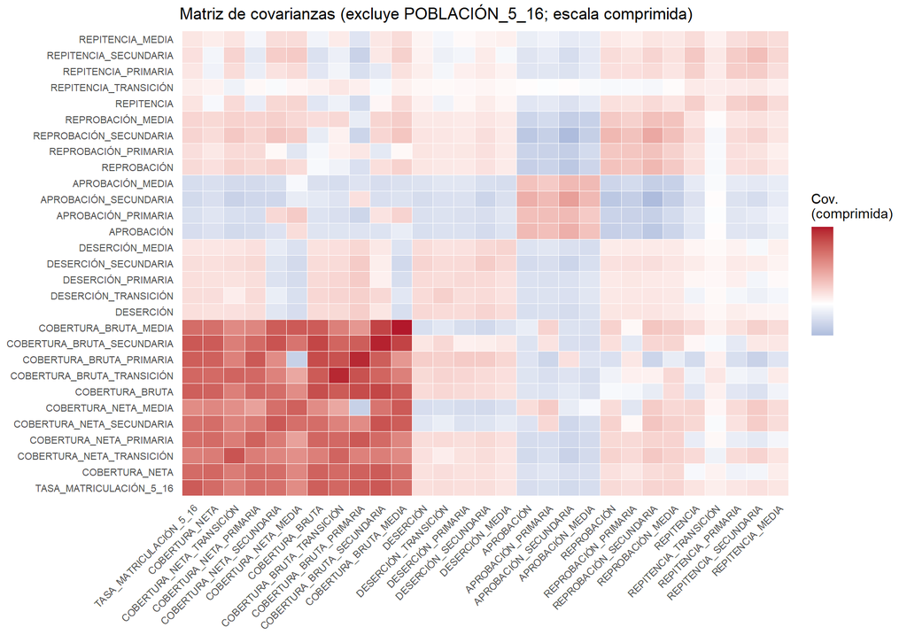

## 8. Distancias de Mahalanobis

Detalle de distancias de Mahalanobis

| Fila | Mahalanobis |
| --- | --- |
| 1 | 38.8055 |
| 2 | 37.2446 |
| 3 | 33.0533 |
| 4 | 30.6113 |
| 5 | 45.9393 |
| 6 | 30.5789 |
| 7 | 25.6575 |
| 8 | 137.5593 |
| 9 | 18.0973 |
| 10 | 25.5457 |
| 11 | 38.2198 |
| 12 | 26.4186 |
| 13 | 29.5878 |
| 14 | 21.0797 |
| 15 | 34.9665 |
| 16 | 20.4596 |
| 17 | 52.6260 |
| 18 | 23.5671 |
| 19 | 13.8078 |
| 20 | 33.1471 |
| 21 | 21.1244 |
| 22 | 40.9861 |
| 23 | 30.7173 |
| 24 | 17.0515 |
| 25 | 25.5375 |
| 26 | 42.7876 |
| 27 | 48.4852 |
| 28 | 27.1347 |
| 29 | 28.3850 |
| 30 | 24.5119 |

[output cut: 5033 more lines]

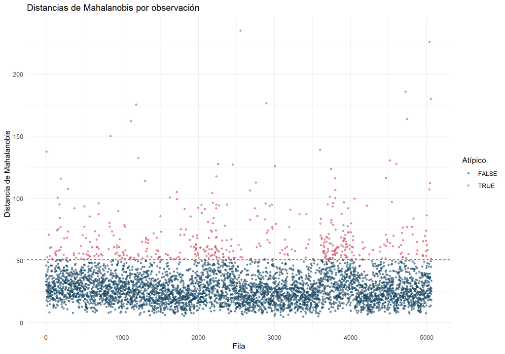

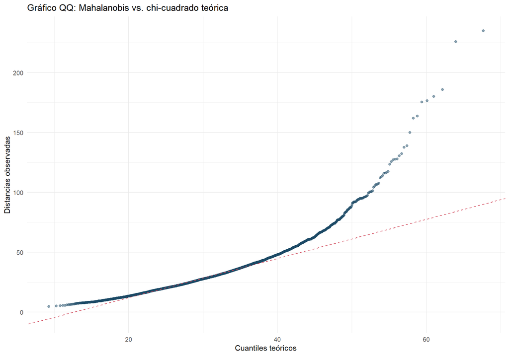

## 9. Conclusiones integradas

1. Los códigos geográficos se trataron como categóricos y las variables constantes de transición se excluyeron de los cálculos multivariados.
2. Las coberturas y aprobaciones concentran sus valores en niveles altos, mientras que deserción, reprobación y repitencia presentan distribuciones más bajas y asimétricas.
3. Las relaciones de aprobación-reprobación muestran una asociación negativa consistente; las relaciones entre indicadores del mismo fenómeno permiten identificar patrones por nivel educativo.
4. La matriz de correlaciones permite detectar bloques de indicadores asociados, mientras que la matriz de covarianzas conserva el efecto de las escalas originales.
5. Las distancias de Mahalanobis resumen la rareza multivariada de cada fila completa; los casos que superan el umbral chi-cuadrado del 99% requieren revisión territorial y sustantiva antes de considerarse anomalías.